# Math 421 - Midterm

## Instruction

The midterm has two components: the Rmarkdown notebook (html) and the presentation. We will do the presentation in class. Post both the notebook and the presentation on your Github page.

**The notebook:** The notebook should be created using `rmarkdown` or Quarto (like other assignments). The notebook should have a title.

**The Presentation:** Present your results in 5-10 minutes. To make the presentation using Rmarkdown, do the follows:

```
- In Rstudio -> File -> New File -> R markdown

- In the left panel, click to Presentation -> Click OK

- Now you have an Rmarkdown that can be knitted to be a html presentation
```

- You can also use the Rmd templates of the class slides.
- You can also use Quarto to create the presentation: *In Rstudio -> File -> New File -> Quarto Presentation…*
- You do not need to rerun all the codes for the presentation. For example, to show the model comparison, you just need to show the image of the model comparison instead of running all the models again.
- To inset an image in a slide, use `![](image.png)`
- To scale images, you can use `![](image.png){width="60%"}` or follow these below instructions.
  - https://bookdown.org/yihui/rmarkdown-cookbook/figure-size.html
  - http://zevross.com/blog/2017/06/19/tips-and-tricks-for-working-with-images-and-figures-in-r-markdown-documents/
- To turn off message and warning of a code cell, use: `{r, message=FALSE, warning=FALSE}` for the cell.

**What to present**:

- Present Part 2 - Visualization
- Present Question Question 4, 5 and 6 in Part 3.
- Present any errors/challenges you run into and how you fix/overcome them.

**Data:**

The data for the mid-term project is the Rhode Island Department of Health Hospital Discharge Data. Each row of the data presents a patient.

Link: https://drive.google.com/open?id=15QNBf6YYKocK2nNIfpKDer58kQnCPNZJ

**Notice**

- Since this is a large dataset, you could try to run the codes on the smaller dataset, which is a portion of the original dataset before running the codes on the original data. To create a random subset of the data you could use

```r
# find the number of rows of the data
n = nrow(df)

# subset 1000 rows of the data
df1 = df[sample(1:n, 1000), ]
```

## I. Data Wranggling

1. Download the data file `hdd0318cy.sas7bdat`.
2. Use `read_sas` in library `haven` to read the data.

```r
#commented out at the end so the file would knit
#install.packages('haven')
```

```r
library(haven)

df <- read_sas('hdd0318cy.sas7bdat')
```

3. Filter the data to have only patients of the year 2018 (`yod=18`)

```r
#commented out at the end so the file would knit
#install.packages('dplyr')
#install.packages('tidyverse')
```

```r
library(dplyr)
library(tidyverse)
```

```r
df18 <- df %>%
     filter(yod == 18)
```

4. Select to work with only following variables:

```
#commented out this code

#{r, eval=FALSE}
 #                     "yod","payfix","pay_ub92","age",
  #                    "sex","raceethn","provider","moa",
   #                   "yoa","mod","admtype", "asource" ,
    #                  "preopday" ,"los", "service" , "icu","ccu",
     #                 "dispub92", "payer"  ,"drg","trandb",
      #                "randbg","randbs","orr", "anes","seq",
       #               "lab","dtest", "ther","blood","phar",
        #              "other","patcon","bwght","total","tot" ,
         #             "ecodub92","b_wt","pt_state","diag_adm","ancilar" ,
          #            "campus","er_fee","er_chrg","er_mode","obs_chrg",
           #           "obs_hour","psycchrg","nicu_day"
```

```r
df18_selected <- df18[, c("yod","payfix","pay_ub92","age",
                      "sex","raceethn","provider","moa",
                      "yoa","mod","admtype", "asource" ,
                      "preopday" ,"los", "service" , "icu","ccu",
                      "dispub92", "payer"  ,"drg","trandb",
                      "randbg","randbs","orr", "anes","seq",
                      "lab","dtest", "ther","blood","phar",
                      "other","patcon","bwght","total","tot" ,
                      "ecodub92","b_wt","pt_state","diag_adm","ancilar" ,
                      "campus","er_fee","er_chrg","er_mode","obs_chrg",
                      "obs_hour","psycchrg","nicu_day")]
```

*Notice*: You may want to save the current data to your computer for easy access later. To save the data file use `write_csv(df, 'midterm.csv')`, for example. Also notice that, empty values in the data before writing to csv may turn to NAs later when you re-read the file.

```r
write_csv(df, 'midterm1.csv')
write_csv(df18, 'midterm2.csv')
write_csv(df18_selected, 'midterm3.csv')
```

5. What are variables that have missing values?

```r
colSums(is.na(df18_selected))
```

```
##      yod   payfix pay_ub92      age      sex raceethn provider      moa
##        0   131478        0        0        0        0        0        0
##      yoa      mod  admtype  asource preopday      los  service      icu
##        0        0        0        0    60486        0        0        0
##      ccu dispub92    payer      drg   trandb   randbg   randbs      orr
##        0        0        0        0        0        0        0        0
##     anes      seq      lab    dtest     ther    blood     phar    other
##        0        0        0        0        0        0        0        0
##   patcon    bwght    total      tot ecodub92     b_wt pt_state diag_adm
##        0        0        0        0        0        0        0        0
##  ancilar   campus   er_fee  er_chrg  er_mode obs_chrg obs_hour psycchrg
##        0        0        0        0        0        0    77343        0
## nicu_day
##   124090
```

#payfix, preopday, obs_hour, and nicu_day have missing values

6. Remove all variables with missing values.

```r
df18_selected <- df18_selected %>%
  select(-payfix, -preopday, -obs_hour, -nicu_day)
```

7. Refer to the data description in the file `HDD2015-18cy6-20-19.docx`, which variable recording the month of admission?, which variable recording the month of discharge? #MOA / moa indicates month of admission, while MOD / mod indicates month of #discharge.
8. Which month admitted the most number of patients? Which month admitted the most number of male patients?

```r
df18_selected %>% count(moa)
```

```
## # A tibble: 12 × 2
##      moa     n
##    <dbl> <int>
##  1     1 11309
##  2     2 10259
##  3     3 11073
##  4     4 11174
##  5     5 11404
##  6     6 10690
##  7     7 10962
##  8     8 11199
##  9     9 10666
## 10    10 11408
## 11    11 10636
## 12    12 10698
```

#The most patients were admitted in October (11,408).

```r
df18_selected %>%
  filter(sex=='1') %>%
  count(moa) %>%
  arrange(-n)
```

```
## # A tibble: 12 × 2
##      moa     n
##    <dbl> <int>
##  1    10  5164
##  2     5  5066
##  3     8  5028
##  4     4  4989
##  5     3  4978
##  6     1  4970
##  7     7  4910
##  8    12  4855
##  9     6  4810
## 10    11  4800
## 11     9  4683
## 12     2  4546
```

#October admitted the most male patients (5,164).

9. Which month has the most number of teenage female patients?

```r
df18_selected %>%
  filter(sex=='2') %>%
  filter(age >= 13 & age <= 19) %>%
  count(moa) %>%
  arrange(-n)
```

```
## # A tibble: 12 × 2
##      moa     n
##    <dbl> <int>
##  1     3   226
##  2     5   220
##  3    10   212
##  4    12   208
##  5     1   207
##  6     9   196
##  7     4   187
##  8    11   177
##  9     2   172
## 10     8   172
## 11     7   171
## 12     6   169
```

#March had the highest number of teenage female patients admitted.

10. Which provider has the most number of female patients in October?

```r
df18_selected %>%
  filter(sex=='2') %>%
  filter(moa=='10') %>%
  count(provider) %>%
  arrange(-n)
```

```
## # A tibble: 12 × 2
##    provider     n
##    <chr>    <int>
##  1 7205      1517
##  2 7214      1224
##  3 7204       872
##  4 7210       699
##  5 7209       351
##  6 7206       333
##  7 7213       317
##  8 7201       294
##  9 7216       256
## 10 7202       212
## 11 7211       122
## 12 7215        46
```

#Provider 7205 (Rhode Island Hospital) had the highest number of female #patients admitted in October.

11. Are female patients older than male patients, on average?

```r
df18_selected %>%
  group_by(sex) %>%
  summarise(mean_age = mean(age))
```

```
## # A tibble: 3 × 2
##   sex   mean_age
##   <chr>    <dbl>
## 1 1         51.5
## 2 2         50.9
## 3 9         43
```

#No, male patients are on average older.

12. Calculate the average age of patients by months. Which month has the oldest patients on average age?

```r
df18_selected %>%
  group_by(moa) %>%
  summarise(mean_age = mean(age)) %>%
  arrange(-mean_age)
```

```
## # A tibble: 12 × 2
##      moa mean_age
##    <dbl>    <dbl>
##  1     1     51.8
##  2     6     51.5
##  3    12     51.5
##  4     4     51.4
##  5     7     51.3
##  6     2     51.2
##  7     3     51.1
##  8    11     51.0
##  9     8     50.9
## 10    10     50.8
## 11     5     50.6
## 12     9     50.6
```

#January on average has the oldest patients.

13. What is the name of the provider that has the highest total charge?

```r
df18_selected %>%
  group_by(provider) %>%
  count(tot) %>%
  arrange(-tot)
```

```
## # A tibble: 107,649 × 3
## # Groups:   provider [12]
##    provider     tot     n
##    <chr>      <dbl> <int>
##  1 7214     3402056     1
##  2 7205     2991708     1
##  3 7205     2721862     1
##  4 7215     2418518     1
##  5 7214     2293855     1
##  6 7214     2184238     1
##  7 7214     2085582     1
##  8 7214     2056748     1
##  9 7214     2038622     1
## 10 7205     2018626     1
## # ℹ 107,639 more rows
```

14. What is the name of the provider that has the least total charge for teenage male on average?

```r
df18_selected %>%
  filter(sex=='1') %>%
  filter(age >= 13 & age <= 19) %>%
  group_by(provider) %>%
  summarise(mean_tot = mean(tot)) %>%
  arrange(-mean_tot)
```

```
## # A tibble: 12 × 2
##    provider mean_tot
##    <chr>       <dbl>
##  1 7215      100440.
##  2 7205       40215.
##  3 7202       29389.
##  4 7214       28950
##  5 7209       26573.
##  6 7204       24989.
##  7 7216       24060.
##  8 7213       22618.
##  9 7211       19742.
## 10 7210       18586.
## 11 7201       14434.
## 12 7206       10360.
```

#Provider 7206 (Roger Williams) has the least total charge for teenage males #on average.

15. Create a season (Spring, Summer, Fall, Winter) variable. Calculate the length of stays by season. Which season has the longest length of stays on average?

```r
#comment out this code block
#library(dplyr)

#My first attempt
#df18_selected <- df18_selected %>%
 # mutate(
  #  Spring = if_else(moa == value, 3, 4, 5))

#df18_selected <- df18_selected %>%
 # mutate(
  #  Summer = if_else(moa == value, 6, 7, 8))

#df18_selected <- df18_selected %>%
 # mutate(
  #  Fall = if_else(moa == value, 9, 10, 11))

#df18_selected <- df18_selected %>%
 # mutate(
  #  Winter = if_else(moa == value, 12, 1, 2))
```

```r
#Chat GPT's suggestion based on my efforts that didn't work:

df18_selected <- df18_selected %>%
  mutate(
    season = case_when(
      moa %in% c(12, 1, 2) ~ "Winter",
      moa %in% c(3, 4, 5)  ~ "Spring",
      moa %in% c(6, 7, 8)  ~ "Summer",
      moa %in% c(9,10,11)  ~ "Fall",
      TRUE                ~ NA_character_
    )
  )
```

```r
df18_selected %>%
  group_by(season) %>%
  summarise(mean_los = mean(los)) %>%
  arrange(-mean_los)
```

```
## # A tibble: 4 × 2
##   season mean_los
##   <chr>     <dbl>
## 1 Summer     4.96
## 2 Fall       4.96
## 3 Winter     4.93
## 4 Spring     4.84
```

#Summer has the longest stays on average.

16. On average, how much a 20 year-old male get charged for staying 1 day in the Fall season?

```r
df18_selected %>%
  filter(sex=='1') %>%
  filter(age == '20') %>%
  filter(season == 'Fall') %>%
  filter(los == '1') %>%
  summarise(mean_tot = mean(tot))
```

```
## # A tibble: 1 × 1
##   mean_tot
##      <dbl>
## 1    16511
```

#In this scenario, the average charge is $16,511.

17. Write a paragraph to summarize the section and give your comments on the results. You could do some other calculations to support your points. # This section of the midterm dealt primarily with data wrangling, which # involves manipulating datasets and specific pieces of data to answer certain # questions. A good first step is to get the data into an easy to work with # format. This involves getting the data into R Studio, considering the values, # and dealing with missing values. Next, the user can come up with questions # the data could be used to answer. In this midterm assignment, questions were # considered regarding Rhode Island hospital discharge data. Variables included # many pieces of information, including month of admission, age, sex, total # charge, year, and provider. Despite the original dataset having over 2 # million observations, I was able to reduce the data to a smaller set that # was easier to work with for specific purposes, such as selecting only data # from 2018. I was pleasantly surprised how easy it was to use functions such # as filter, summarize, group_by, and arrange to quickly answer my questions. # I also added another variable for Season by easily using R’s functions. I # actually found completing this assignment to be pretty enjoyable rather than # frustrating because of the ease of use with R Studio. It was definitely # interesting to consider different healthcare scenarios. This data might even # be useful for me if I ever need to consider a hospital stay. For instance, # it was insightful to see the average total charges depending on different # providers. The calculation I did below could be if I myself needed to stay # in a hospital for 1 day. If I was most concerned about the cost, I should go # to South County Hospital (provider 7209).

```r
df18_selected %>%
  filter(sex=='2') %>%
  filter(age == '22') %>%
  filter(season == 'Winter') %>%
  filter(los == '1') %>%
  group_by(provider) %>%
  summarise(mean_tot = mean(tot))
```

```
## # A tibble: 5 × 2
##   provider mean_tot
##   <chr>       <dbl>
## 1 7201        8457
## 2 7204       10198
## 3 7205       13843.
## 4 7209        6938
## 5 7210       12631
```

## II. Data Visualization

Continue with the data from part I.

1. Provides at least 10 meaningful plots. Comments on the plots. All plots should have title, caption, appropriate labels on x and y-axis

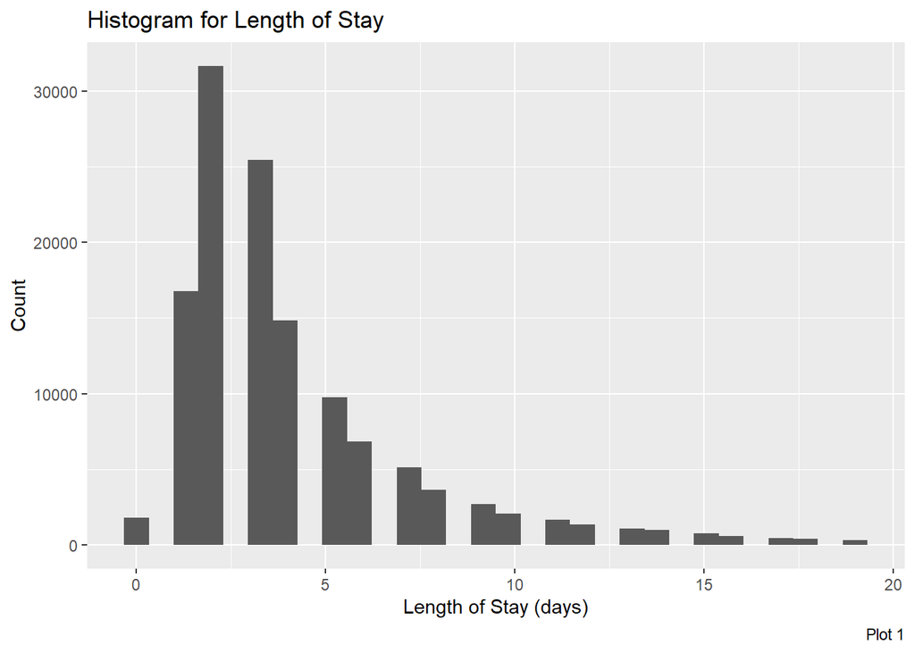

```r
#Plot 1: One continuous variable (histogram)

df18_selected %>% filter(los<20) %>% ggplot()+
  geom_histogram(mapping = aes(x = los))+

labs(x = 'Length of Stay (days)',
     y = 'Count',
     fill = 'los',
     title = 'Histogram for Length of Stay',
       caption = 'Plot 1')
```

#This is a histogram of length of stay. The y-axis measures how many instances #there are of a patient staying for a certain length of time. I filtered the #graph so most of the data could be captured in a frame to make it appear #larger. Beyond 20 days, there were a lot less instances.

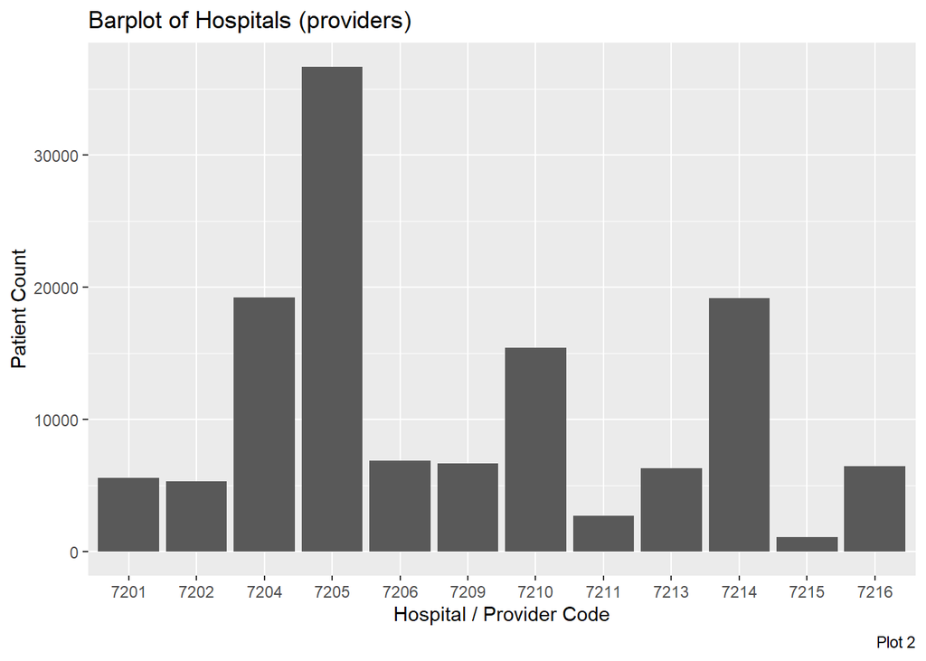

```r
#Plot 2: One Categorical Variable (barplot)

df18_selected %>% ggplot()+
  geom_bar(mapping = aes(x = provider))+

  labs(x = 'Hospital / Provider Code',
     y = 'Patient Count',
     fill = 'provider',
     title = 'Barplot of Hospitals (providers)',
       caption = 'Plot 2')
```

#This is a barplot with the provider on the x-axis. This is a one-variable #graph, so the patient count at each hospital (provider) is listed on the #y-axis. This shows that some patients (like 7205) have many more patients than #other hospitals, possibly due to the type of care provided.

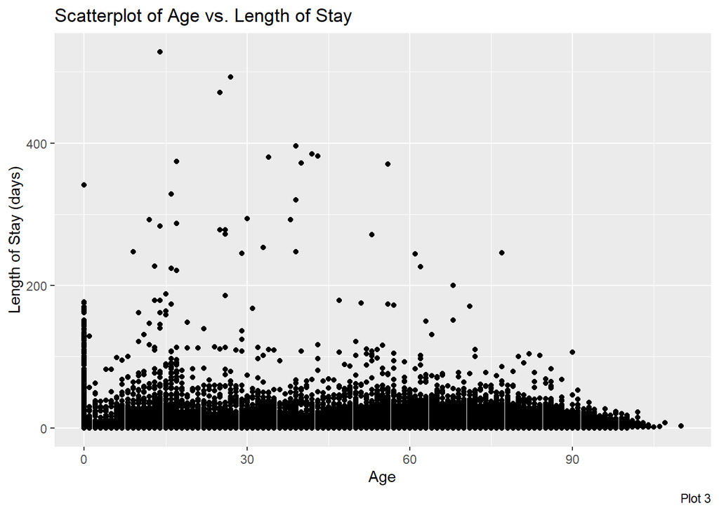

```r
#Plot 3: 2 Continuous Variables (Scatterplot)

df18_selected %>% ggplot()+
  geom_point(mapping = aes(x = age,
                           y = los))+

    labs(x = 'Age',
     y = 'Length of Stay (days)',
     title = 'Scatterplot of Age vs. Length of Stay',
       caption = 'Plot 3')
```

#This is a scatterplot of Age vs. Length of Stay (days). There appear to be #longer stays for people lower in the graph, which surprised me. There are also #more outlying values on the lower end, which might indicate that people are #willing to spend more efforts saving the lives of young people. This could also #reflect that there are nursing-home-like facilities for young people as an #alternative to hospitals.

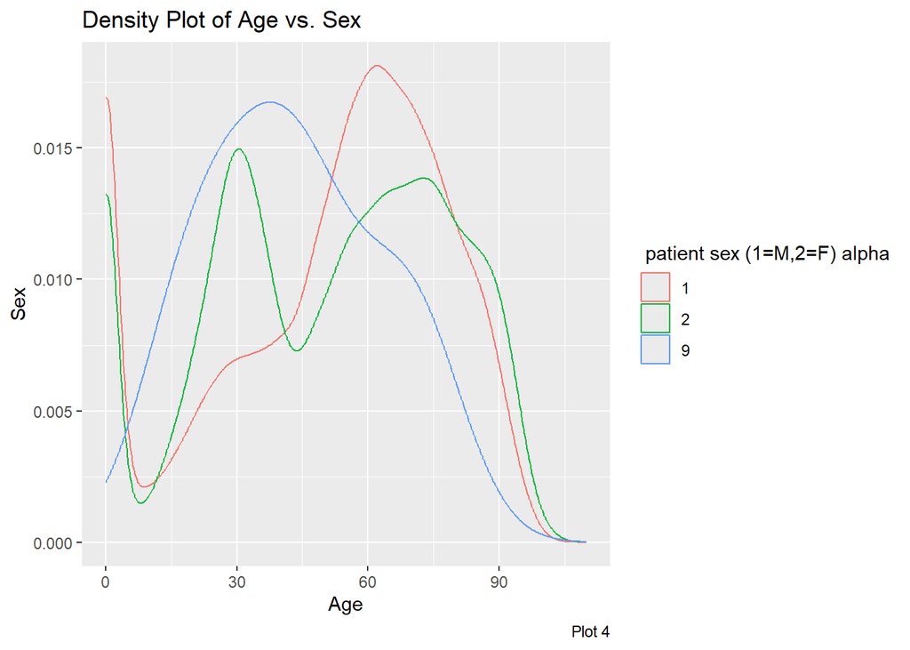

```r
#Plot 4: One Continuous and One Categorical Variable (Density)

df18_selected %>% ggplot()+
  geom_density(mapping = aes(x = age, color = sex))+

    labs(x = 'Age',
     y = 'Sex',
     fill = 'Sex',
     title = 'Density Plot of Age vs. Sex',
       caption = 'Plot 4')
```

#This is a density plot with Age on the x-axis and Sex on the y-axis. The #purpose of this graph is to show where certain values are more common. The #peak appears to be age 60 for sex=1 (male).

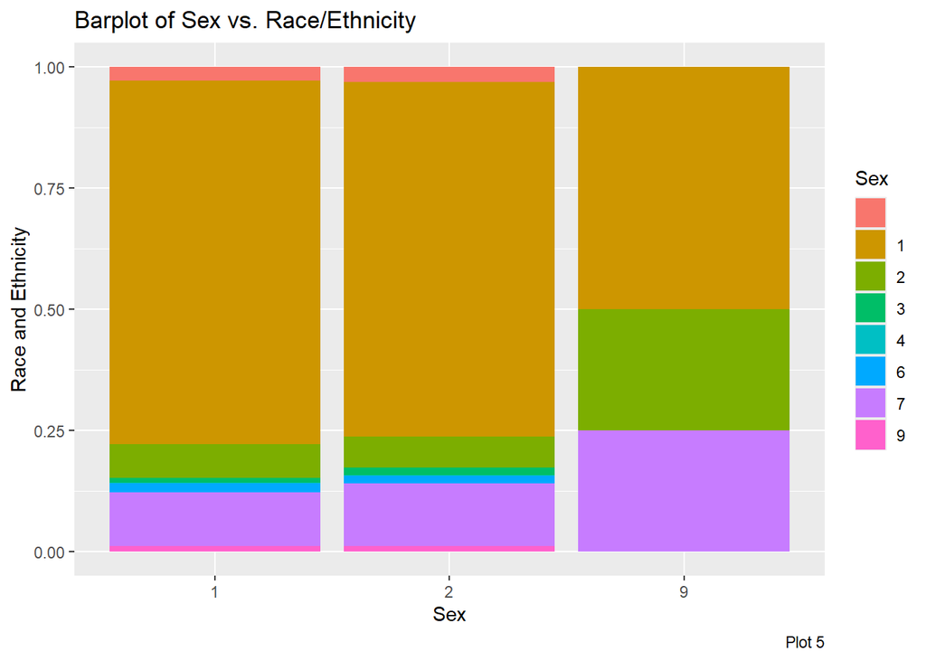

```r
#Plot 5: 2 Categorical Variables (Barplot)

df18_selected %>% ggplot()+
  geom_bar(mapping=aes(x=sex, fill=raceethn), position = 'fill') +

     labs(x = 'Sex',
     y = 'Race and Ethnicity',
     fill = 'Sex',
     title = 'Barplot of Sex vs. Race/Ethnicity',
       caption = 'Plot 5')
```

#This is a barplot of Sex vs. Race/Ethnicity. This plot is useful because it #shows which Sex and Race/Ethnicity combinations are more or less common. The #most common combinations are white men and white women.

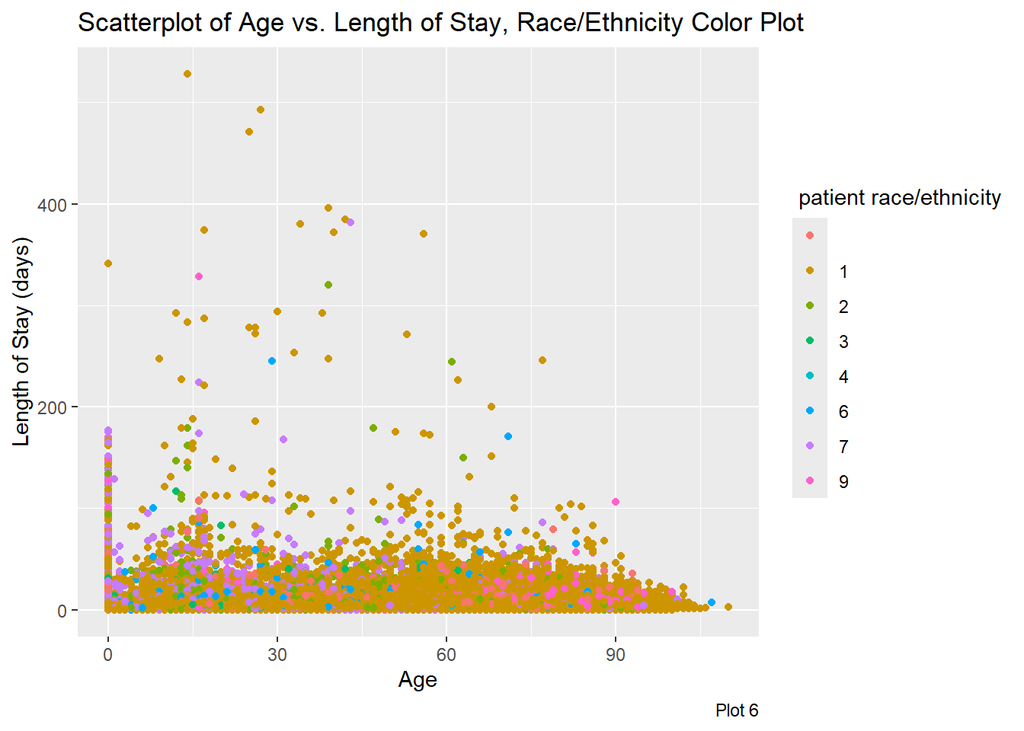

```r
#Plot 6: Three Variables (Scatterplot)

df18_selected %>% ggplot() + geom_point(aes(x=age, y=los, color = raceethn))+

       labs(x = 'Age',
     y = 'Length of Stay (days)',
     fill = 'Race/Ethnicity',
     title = 'Scatterplot of Age vs. Length of Stay, Race/Ethnicity Color Plot',
       caption = 'Plot 6')
```

#This is a scatterplot for Age vs. Length of Stay with an added factor of Race/ #Ethnicity. This is similar to an earlier plot with the added factor of Race/ #Ethnicity. It’s hard to tell if there are any trends with Race/Ethnicity since #the graph is so overwhelmed by the yellow color.

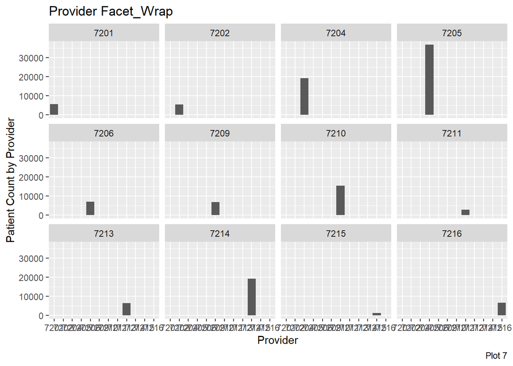

```r
#Plot 7: Facet_wrap of 1 Categorical Variable

df18_selected %>% ggplot()+
  geom_bar(mapping=aes(x=provider))+
  facet_wrap(~provider)+

     labs(x = 'Provider',
     y = 'Patient Count by Provider',
     fill = 'Provider',
     title = 'Provider Facet_Wrap',
       caption = 'Plot 7')
```

#This set of plots shows a facet_wrap plot of providers. There is only one #variable, so the count of patients per providers (rows mentioning the provider) #is set on the y-axis. This is another good visual showing how some providers #have many more patients (ex: 7205).

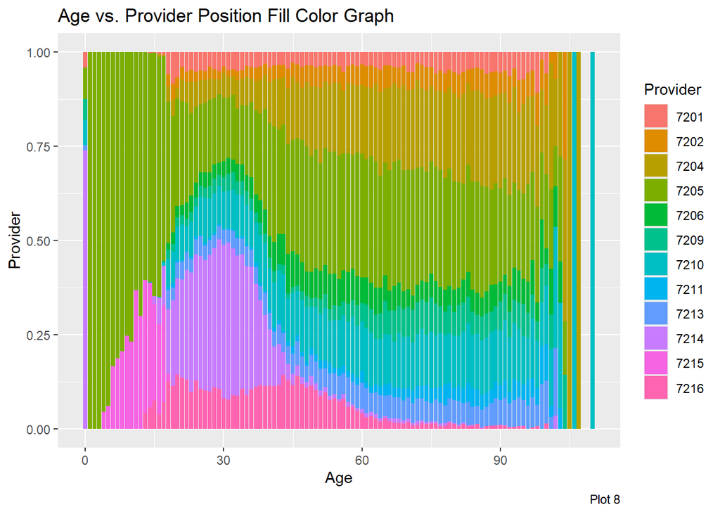

```r
#Plot 8: Position Fill

df18_selected %>% ggplot()+
  geom_bar(mapping=aes(x=age, fill=provider),
           position = 'fill')+

   labs(x = 'Age',
     y = 'Provider',
     fill = 'Provider',
     title = 'Age vs. Provider Position Fill Color Graph',
       caption = 'Plot 8')
```

#This graph is a position fill graph analyzing Age and Provider. It is notable #that certain ages are more likely to visit certain providers. For example, #there are a lot of people around age 30 visiting provider 7214 (Women and #Infants), which makes sense. This is a nice visual to display data through #the use of color.

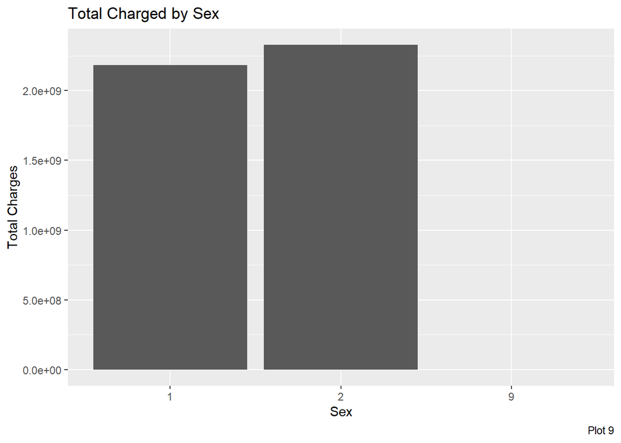

```r
#Plot 9: Geom_col Plot

df18_selected %>% ggplot()+
  geom_col(mapping=aes(x=sex, y=tot))+

   labs(x = 'Sex',
     y = 'Total Charges',
     fill = 'Sex',
     title = 'Total Charged by Sex',
       caption = 'Plot 9')
```

#This geom_col plot show sex on the x-axis and total charges on the y-axis. #This is a nice vertical visual of the different values. It is notable that #the total charges for sex=2 (female) is slightly higher than that of males.

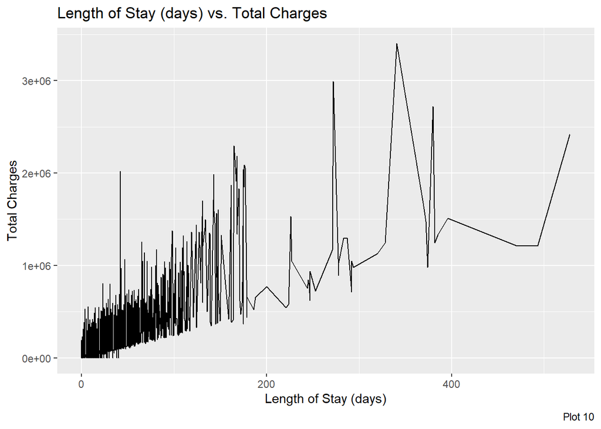

```r
#Plot 10: 2 Continuous Variables (Line plot)

df18_selected %>% ggplot()+
  geom_line(mapping = aes(x = los,
                          y = tot))+

    labs(x = 'Length of Stay (days)',
     y = 'Total Charges',
     fill = 'los',
     title = 'Length of Stay (days) vs. Total Charges',
       caption = 'Plot 10')
```

#This plot shows length of stay (days) on the x-axis with total charges on the #y-axis in the form of a line plot. This connects adjacent points, which #provides a good visual for outliers. A notable trend is that total charges #tend to be higher when the length of stay (days) is higher, which makes sense.

2. Make an animation plot.

```r
#commented out at the end so the file would knit

#install.packages("gganimate")  # only need to do once
#library(gganimate)
```

```r
#commented out at the end so the file would knit

#install.packages(c("gganimate", "ggplot2", "gifski"))
```

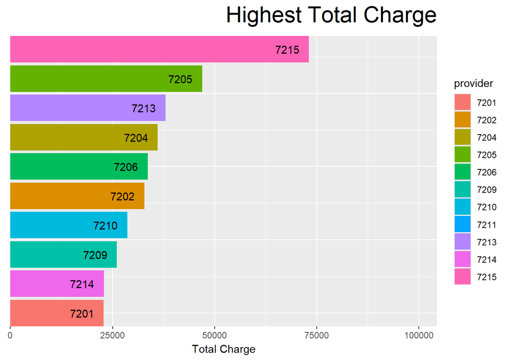

```r
library(gganimate)


df18 <- df18

library(lubridate)
library(dplyr)
library(ggplot2)


d1 <- df18 %>% group_by(moa, provider) %>% summarise(mean = mean(tot))
d2 <- d1 %>% group_by(moa) %>% mutate(rank=rank(-mean))
d3 <- d2 %>% filter(rank <= 10)

a1 <- d3 %>% ggplot(aes(x=rank, y=mean, group=provider, fill=provider, label=provider)) + geom_col()+
    geom_text(aes(y = mean, label = provider), hjust = 1.4)+
    coord_flip(clip = "off", expand = FALSE) +scale_x_reverse()+
    labs(title = 'Highest Total Charge', x='', y='Total Charge', fill='provider')+
    theme(plot.title = element_text(hjust = 1, size = 22),
          axis.ticks.y = element_blank(),
          axis.text.y  = element_blank()) +
    transition_states(moa)+
    ease_aes("cubic-in-out")

animate(a1, nframes = 400)
```

#This plot shows how the highest total charge of different providers changes #by moa (month of admission). This particular graph measures the top 10 values #as they change over time. Some providers notably stay near the top, such as #7215 and 7205. The charge is shown on the x-axis.

3. Write a paragraph to summarize the section and give your comments on the results. #This section dealt with data visualization. In order to effectively visualize #data, R Studio provides a wide variety of options. This section explored #plot forms such as barplots, histograms, scatterplots, line plots, and even #a moving animation bar plot. It is important to also remember to include good #labels on plots, including the title, axes, and captions. I rather enjoyed #seeing the outcomes of these plots, especiallly the colored graphs. I was #also quite pleased with the numerical results, which nicely showed #relationships between a variety of variables. Some general tips for this #section could include using filters as needed, making sure the correct #packages are loaded for different plots, and using colors and other visual #enhancements to improve the appearance of the data.

## III. Predictive Models

Continue with the data from part I. Make sure you do not have any missing values in the data. Use the follows as the target and input variables:

*Target Variable*: Create the target variable taking value of

- `low` if the total charge of a patient (`tot`) is smaller than the median of the total charge, and
- `high` otherwise.

*Input Variables*:

- “age”,“sex”,“raceethn”,“provider”,“moa”,“mod”,“admtype”,“campus”, ‘los’
1. Use `filter` function to filter out rows where `raceethn==''` or `admtype==''`. Make sure all the categorical variables are factor, numeric variables are numeric. Set Training : Testing Split = 10 : 90

```r
#commented out at the end so the file would knit
#library(dplyr)
#
#df18_selected <- df18_selected %>%
 # mutate(
  #  target = if_else(
   #   target < median(target, na.rm = TRUE),
    #  "low",
     # "high"
 #   )
 # )
```

```r
#commented out at the end so the file would knit
#df18_selected$target <- factor(df18_selected$target, levels = c("low", "high"))
```

```r
df18_selected <- df18_selected %>%
  filter(raceethn != "")

df18_selected <- df18_selected %>%
  filter(admtype != "")
```

```r
df18_selected$sex <- as.factor(df18_selected$sex)
df18_selected$raceethn <- as.factor(df18_selected$raceethn)
df18_selected$provider <- as.factor(df18_selected$provider)
df18_selected$admtype <- as.factor(df18_selected$admtype)
df18_selected$campus <- as.factor(df18_selected$campus)

df18_selected$age <- as.numeric(df18_selected$age)
df18_selected$moa <- as.numeric(df18_selected$moa)
df18_selected$mod <- as.numeric(df18_selected$mod)
df18_selected$los <- as.numeric(df18_selected$los)
```

```r
modl <- function(input_data, train_percent, predictors) {

  set.seed(123)
  n <- nrow(input_data)
  train_id <- sample(seq_len(n), size = floor(train_percent * n))

  train <- input_data[train_id, ]
  test  <- input_data[-train_id, ]

  # Build formula
  form <- as.formula(
    paste("target ~", paste(predictors, collapse = " + "))
  )

  model <- glm(form, data = train, family = binomial)

  list(
    model = model,
    train = train,
    test  = test
  )
}
```

```r
#commented out at end so file would knit

#predictors <- c(
 # "age","sex","raceethn","provider","moa",
  #"mod","admtype","campus","los"
#)

#result <- modl(
#  input_data   = df18_selected,
 # train_percent = 0.1,
  #predictors    = predictors
#)
```

```r
modl <- function(input_data, train_percent) {

  library(caret)
  library(rpart)
  library(rattle)

  set.seed(123)

  splitIndex <- createDataPartition(input_data$target,
                                    p = train_percent,
                                    list = FALSE)

  df_train <- input_data[splitIndex, ]
  df_test  <- input_data[-splitIndex, ]

  df_train$target <- as.factor(df_train$target)

  tree1 <- rpart(target ~ ., data = df_train)

  print(fancyRpartPlot(tree1))

  invisible(tree1)
}
```

```r
#commented out at the end so file would knit
#modl(df18_selected, 0.1)
```

3. Using caret for this question. Set `Training Control` to be: Use Cross-Validation of 5 folds across all models. Train & tune at least 2 different models (i.e. two different values for `method=` in the train function of caret). Plot the hyper-parameter tuning plots for each model.

```r
library(caret)

train_control <- trainControl(
  method = "cv",
  number = 5
)
```

```r
#commented out at the end so the file would knit
#model_tree <- train(
 # target ~ .,
  #data = df_train,
  #method = "rpart",
  #trControl = train_control
#)
```

```r
#commented out at end so file would knit
#model_logit <- train(
 # target ~ .,
  #data = df_train,
  #method = "glm",
  #family = binomial,
  #trControl = train_control
#)
```

```r
#commented out at end so file would knit

#plot(model_tree)
```

```r
#commented out at end so file would knit

#model_glm <- train(
 # target ~ .,
  #data = df_train,
#  method = "glmnet",
 # trControl = train_control,
  #tuneLength = 10
#)

#plot(model_glm)
```

4. Plot the comparison of the models in 3.

```r
#commented out at end so file would knit

#library(caret)

## Example: 5-fold CV training control
#train_control <- trainControl(method = "cv", number = 5)

## Decision tree
#model_tree <- train(
 # target ~ .,
  #data = df_train,
#  method = "rpart",
 # trControl = train_control,
  #tuneLength = 10
#)

## Logistic regression
#model_glm <- train(
 # target ~ .,
  #data = df_train,
#  method = "glm",
 # trControl = train_control
#)

## Random forest
#model_rf <- train(
 # target ~ .,
  #data = df_train,
#  method = "rf",
 # trControl = train_control,
  #tuneLength = 5
#)
```

```r
#commented out at end so file would knit

## Combine models
#models_list <- list(
 # DecisionTree = model_tree,
#  Logistic     = model_glm,
 # RandomForest = model_rf
#)

## Use caret's resamples()
#resamps <- resamples(models_list)

## Summary of performance
#summary(resamps)
```

```r
#commented out at end so file would knit

## Boxplots of accuracy for each model
#bwplot(resamps, metric = "Accuracy")

## Dotplot (alternative)
#dotplot(resamps, metric = "Accuracy")
```

```r
#commented out at end so file would knit

#df_test$target <- as.factor(df_test$target)
```

```r
#commented out at end so file would knit

## For class predictions
#pred_glm <- predict(model_glm, newdata = df_test)
```

```r
#commented out at end so file would knit

#pred_glm_prob <- predict(model_glm, newdata = df_test, type = "prob")
```

```r
#
#library(caret)

#conf_mat_glm <- confusionMatrix(pred_glm, df_test$target)
#conf_mat_glm
```

```r
#commented out at end so file would knit

#accuracy_glm <- conf_mat_glm$overall['Accuracy']
#accuracy_glm
```

6. Create another `target` variable (binary), decide the input variables and redo 1 to 5.

```r
#commented out at end so file would knit

####Part 1:
#library(dplyr)

#df18_selected <- df18_selected %>%
 # mutate(
  #  target2 = if_else(
   #   trandb < median(trandb, na.rm = TRUE),
    #  "low",
     # "high"
#    )
 # )
```

```r
#commented out at end so file would knit

#df18_selected$target2 <- factor(df18_selected$target2, levels = c("low", "high"))
```

```r
#commented out at end so file would knit

#df18_selected <- df18_selected %>%
 # filter(raceethn != "")

#df18_selected <- df18_selected %>%
 # filter(admtype != "")
```

```r
#commented out at end so file would knit

#df18_selected$sex <- as.factor(df18_selected$sex)
#df18_selected$raceethn <- as.factor(df18_selected$raceethn)
#df18_selected$provider <- as.factor(df18_selected$provider)
#df18_selected$season <- as.factor(df18_selected$season)



#df18_selected$age <- as.numeric(df18_selected$age)
#df18_selected$moa <- as.numeric(df18_selected$moa)
#df18_selected$mod <- as.numeric(df18_selected$mod)
#df18_selected$los <- as.numeric(df18_selected$los)
```

```r
#commented out at end so file would knit

#modl <- function(input_data, train_percent, predictors) {

 # set.seed(123)
  #n <- nrow(input_data)
#  train_id <- sample(seq_len(n), size = floor(train_percent * n))

 # train <- input_data[train_id, ]
#  test  <- input_data[-train_id, ]

 # # Build formula
  #form <- as.formula(
#    paste("target2 ~", paste(predictors, collapse = " + "))
 # )

  #model <- glm(form, data = train, family = binomial)

 # list(
  #  model = model,
   # train = train,
    #test  = test
#  )
#}
```

```r
#commented out at end so file would knit

#predictors <- c(
 # "age","sex","raceethn","provider","moa",
  #"mod","season","los"
#)

#result <- modl(
 # input_data   = df18_selected,
  #train_percent = 0.1,
#  predictors    = predictors
#)
```

```r
#commented out at end so file would knit

####Part 2
#modl <- function(input_data, train_percent) {

 # library(caret)
#  library(rpart)
 # library(rattle)

#  set.seed(123)

 # splitIndex <- createDataPartition(input_data$target2,
  #                                  p = train_percent,
   #                                 list = FALSE)

#  df_train <- input_data[splitIndex, ]
 # df_test  <- input_data[-splitIndex, ]

#  df_train$target2 <- as.factor(df_train$target2)

#  tree1 <- rpart(target2 ~ ., data = df_train)

 # print(fancyRpartPlot(tree1))

#  invisible(tree1)
#}
```

```r
#commented out at end so file would knit

# modl(df18_selected, 0.1)
```

```r
#commented out at end so file would knit

##Part 3:
#library(caret)

#train_control <- trainControl(
 # method = "cv",
  #number = 5
#)
```

```r
#commented out at end so file would knit


#model_tree <- train(
 # target ~ .,
  #data = df_train,
#  method = "rpart",
 # trControl = train_control
#)
```

```r
#commented out at end so file would knit

#model_logit <- train(
 # target ~ .,
  #data = df_train,
#  method = "glm",
 # family = binomial,
#  trControl = train_control
#)
```

```r
#commented out at end so file would knit

#plot(model_tree)
```

```r
#commented out at end so file would knit

#model_glm <- train(
 # target ~ .,
#  data = df_train,
#  method = "glmnet",
#  trControl = train_control,
#  tuneLength = 10
#)

#plot(model_glm)
```

```r
#commented out at end so file would knit

##Part 4
#library(caret)

## Example: 5-fold CV training control
#train_control <- trainControl(method = "cv", number = 5)

## Decision tree
#model_tree <- train(
#  target ~ .,
 # data = df_train,
#  method = "rpart",
 # trControl = train_control,
  #tuneLength = 10
#)

## Logistic regression
#model_glm <- train(
#  target ~ .,
 # data = df_train,
  #method = "glm",
 # trControl = train_control
#)

## Random forest
#model_rf <- train(
#  target ~ .,
#  data = df_train,
#  method = "rf",
#  trControl = train_control,
#  tuneLength = 5
#)
```

```r
#commented out at end so file would knit

## Combine models
#models_list <- list(
#  DecisionTree = model_tree,
#  Logistic     = model_glm,
#  RandomForest = model_rf
#)

## Use caret's resamples()
#resamps <- resamples(models_list)

## Summary of performance
#summary(resamps)
```

```r
#commented out at end so file would knit

## Boxplots of accuracy for each model
#bwplot(resamps, metric = "Accuracy")

## Dotplot (alternative)
#dotplot(resamps, metric = "Accuracy")
```

```r
#commented out at end so file would knit

#df_test$target <- as.factor(df_test$target)
```

```r
#commented out at end so file would knit

## For class predictions
#pred_glm <- predict(model_glm, newdata = df_test)
```

```r
#commented out at end so file would knit

#pred_glm_prob <- predict(model_glm, newdata = df_test, type = "prob")
```

```r
#commented out at end so file would knit

#library(caret)

#conf_mat_glm <- confusionMatrix(pred_glm, df_test$target)
#conf_mat_glm
```

```r
#commented out at end so file would knit

#accuracy_glm <- conf_mat_glm$overall['Accuracy']
#accuracy_glm
```